# Data Processing for next step

The original data is a csv table including the count of baby name from each year, each state, and each name. The data for this project is from Kaggle: https://www.kaggle.com/kaggle/us-baby-names. In the original data, the minumum count of the baby name is 5. Any number below 5 is considered as nan in the table. We cleared up the data and picked up the biblical names only. We transformed the data into a list of matrixes, where each matrix represents the name count of a single year, ranging from 1910 to 2014. In each matrix, the column represents the name, and the index represents the state. Therefore each slot is the count of a specific name in a specific state.

```python
# -*- coding: utf-8 -*-
from __future__ import division
import numpy as np
import pandas as pd
from sklearn import linear_model
import matplotlib.pyplot as plt
import matplotlib
import matplotlib.pyplot as plt
from sklearn.metrics import r2_score
from sklearn.cross_validation import train_test_split
%matplotlib inline

## Explore Data
import pickle
f = open('data.pkl', 'rb')
dfList = pickle.load(f)
f.close()
```

```python
df_all = pd.read_csv("StateNames.csv", delimiter=',')
```

We assume that the influence of Christianity is changing over time, which is reflects by the change of biblical names given to the new-born babies. The plots below actually proved our assumption that there is a dramatic falling in 1920s, and peaked at 1980s.

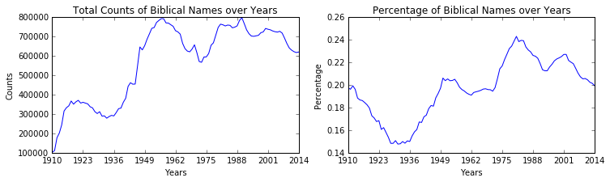

```python
N = len(dfList.keys())
counts_all = np.zeros(N)
counts_nation = np.zeros(N)
for i, year in enumerate(dfList.keys()):
    df_curr = dfList[year]
    counts_all[i] = np.sum(np.sum(df_curr))
    counts_nation[i] = np.sum(df_all[df_all.Year == year].Count)

fig , ax = plt.subplots(1, 2, figsize=(12, 3))
plt.setp(ax, xticks=range(0,N,13), xticklabels=dfList.keys()[0::13])
ax[0].plot(counts_all)
ax[0].set_title('Total Counts of Biblical Names over Years')
ax[0].set_xlabel('Years')
ax[0].set_ylabel('Counts')
ax[1].plot(counts_all/counts_nation)
ax[1].set_title('Percentage of Biblical Names over Years')
ax[1].set_xlabel('Years')
ax[1].set_ylabel('Percentage')
```

In addition to the national trend, we assume that there are noticable differences between the states. Some states may have appreared to be more conservative while others may have been more innovative to new baby names. Therefore we plot the names counts among three sampling states below: California, Massachusetts and Pennsylvania. The reason we picked these three states is because they are representatives of west, middle and east coast.

```
(0.1, 0.35)
```

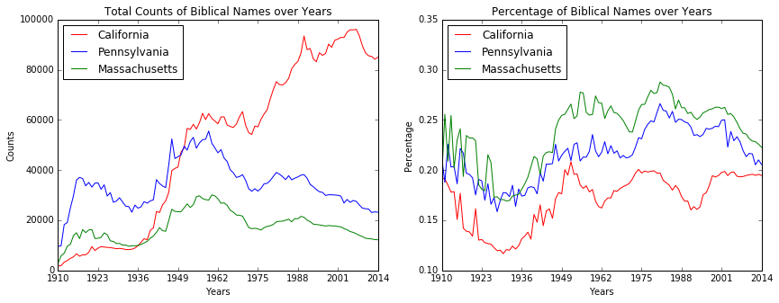

```python
counts_CA = np.zeros(N)
counts_PA = np.zeros(N)
counts_MA = np.zeros(N)
counts_CA_all = np.zeros(N)
counts_PA_all = np.zeros(N)
counts_MA_all = np.zeros(N)

for i, year in enumerate(dfList.keys()):
    df_curr = dfList[year]
    counts_CA[i] = np.sum(df_curr.loc['CA'])
    counts_PA[i] = np.sum(df_curr.loc['PA'])
    counts_MA[i] = np.sum(df_curr.loc['MA'])
    counts_CA_all[i] = np.sum(df_all[(df_all.Year == year) & (df_all.State=='CA')].Count)
    counts_PA_all[i] = np.sum(df_all[(df_all.Year == year) & (df_all.State=='PA')].Count)
    counts_MA_all[i] = np.sum(df_all[(df_all.Year == year) & (df_all.State=='MA')].Count)

fig , ax = plt.subplots(1, 2, figsize=(14, 5))
plt.setp(ax, xticks=range(0,N,13), xticklabels=dfList.keys()[0::13])
ax[0].plot(counts_CA, 'r',label='California')
ax[0].plot(counts_PA, 'b',label='Pennsylvania')
ax[0].plot(counts_MA, 'g',label='Massachusetts')
ax[0].legend(loc='upper left')
ax[0].set_title('Total Counts of Biblical Names over Years')
ax[0].set_xlabel('Years')
ax[0].set_ylabel('Counts')
ax[1].plot(counts_CA/counts_CA_all, 'r',label='California')
ax[1].plot(counts_PA/counts_PA_all, 'b',label='Pennsylvania')
ax[1].plot(counts_MA/counts_MA_all, 'g',label='Massachusetts')
ax[1].legend(loc='upper left')
ax[1].set_title('Percentage of Biblical Names over Years')
ax[1].set_xlabel('Years')
ax[1].set_ylabel('Percentage')
ax[1].set_ylim([0.1,0.35])
```

We also plot the counts of one single name with top count: James, as below. The plots show that the trend of this specific name is also varying from state to state.

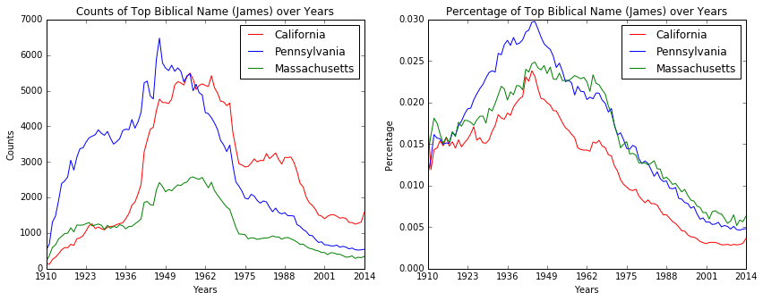

```python
counts_CA_top = np.zeros(N)
counts_PA_top = np.zeros(N)
counts_MA_top = np.zeros(N)
for i, year in enumerate(dfList.keys()):
    df_curr = dfList[year]
    counts_CA_top[i] = np.sum(df_all[(df_all.Year == year) & (df_all.State=='CA') & (df_all.Name=='James')].Count)
    counts_PA_top[i] = np.sum(df_all[(df_all.Year == year) & (df_all.State=='PA')& (df_all.Name=='James')].Count)
    counts_MA_top[i] = np.sum(df_all[(df_all.Year == year) & (df_all.State=='MA')& (df_all.Name=='James')].Count)


fig , ax = plt.subplots(1, 2, figsize=(14, 5))
plt.setp(ax, xticks=range(0,N,13), xticklabels=dfList.keys()[0::13])
ax[0].plot(counts_CA_top, 'r',label='California')
ax[0].plot(counts_PA_top, 'b',label='Pennsylvania')
ax[0].plot(counts_MA_top, 'g',label='Massachusetts')
ax[0].legend(loc='upper right')
ax[0].set_title('Counts of Top Biblical Name (James) over Years')
ax[0].set_xlabel('Years')
ax[0].set_ylabel('Counts')
ax[1].plot(counts_CA_top/counts_CA_all, 'r',label='California')
ax[1].plot(counts_PA_top/counts_PA_all, 'b',label='Pennsylvania')
ax[1].plot(counts_MA_top/counts_MA_all, 'g',label='Massachusetts')
ax[1].legend(loc='upper right')
ax[1].set_title('Percentage of Top Biblical Name (James) over Years')
ax[1].set_xlabel('Years')
ax[1].set_ylabel('Percentage')
```

#### Civil Rights Movement

As the center of community life, Black churches held a leadership role in the Civil Rights Movement. Their history as a focal point for the Black community and as a link between the Black and White worlds made them natural for this purpose.

Rev. Martin Luther King, Jr. was but one of many notable Black ministers involved in the movement. He helped found the Southern Christian Leadership Conference (1957), serving as its first president. King received the Nobel Peace Prize for his efforts to end segregation and racial discrimination through non-violent civil disobedience. He was assassinated in 1968.

```python
df_tmp = pd.DataFrame(index=dfList[1990].index, columns = dfList[1990].columns).fillna(0)
for year in range(1944-10,1954):
    df_tmp = df_tmp.add(dfList[year].fillna(0))
df_civilwar_before = df_tmp.copy(deep=True)

df_tmp = pd.DataFrame(index=dfList[1990].index, columns = dfList[1990].columns).fillna(0)
for year in range(1969,1979+10):
    df_tmp = df_tmp.add(dfList[year].fillna(0))
df_civilwar_after = df_tmp.copy(deep=True)
```

#### Separation of Church and State

Another noticable event in religious history is the "separation of church and state" movement, which became a definitive part of Establishment Clause jurisprudence in Everson v. Board of Education, 330 U.S. 1 (1947), a case that dealt with a state law that allowed government funds for transportation to religious schools. While the ruling upheld the state law allowing taxpayer funding of transportation to religious schools as constitutional, Everson was also the first case to hold the Establishment Clause applicable to the state legislatures as well as Congress, based upon the due process clause of the Fourteenth Amendment.

```python
df_tmp = pd.DataFrame(index=dfList[1990].index, columns = dfList[1990].columns).fillna(0)
for year in range(1937-10,1947):
    df_tmp = df_tmp.add(dfList[year].fillna(0))
df_seperation_before = df_tmp.copy(deep=True)

df_tmp = pd.DataFrame(index=dfList[1990].index, columns = dfList[1990].columns).fillna(0)
for year in range(1948,1958+10):
    df_tmp = df_tmp.add(dfList[year].fillna(0))
df_seperation_after = df_tmp.copy(deep=True)
```

### Over all names

Starting from this line the analysis is over all baby names.

If you want to execute the following scripts, please download the pkl file of all names(~900MB): https://dl.dropboxusercontent.com/u/11051930/data_dump.pkl

```python
f = open('data_dump.pkl', 'rb')
dfList = pickle.load(f)
f.close()
```

#### World War II (1939-1945)

```python
year_before = range(1929, 1939)
year_after = range(1946,1956)

df_tmp = pd.DataFrame(index=dfList[1990].index, columns = dfList[1990].columns).fillna(0)
for year in year_before:
    df_tmp = df_tmp.add(dfList[year].fillna(0))
df_WWII_before = df_tmp.copy(deep=True)

df_tmp = pd.DataFrame(index=dfList[1990].index, columns = dfList[1990].columns).fillna(0)
for year in year_after:
    df_tmp = df_tmp.add(dfList[year].fillna(0))
df_WWII_after = df_tmp.copy(deep=True)
```

```python
df_WWII_before.head(5)
```

|  | Mary | Annie | Anna | Margaret | Helen | Elsie | Lucy | Dorothy | Ruth | Elizabeth | ... | Cebert | Erman | Herold | Donley | Donzel | Edgel | Delmos | Delmus | Coalton | Wyoma |
| --- | --- | --- | --- | --- | --- | --- | --- | --- | --- | --- | --- | --- | --- | --- | --- | --- | --- | --- | --- | --- | --- |
| AK | 323 | 34 | 57 | 105 | 79 | 5 | 28 | 62 | 54 | 96 | ... | 0 | 0 | 0 | 0 | 0 | 0 | 0 | 0 | 0 | 0 |
| AL | 177 | 2279 | 910 | 3729 | 3271 | 610 | 768 | 3068 | 2163 | 2840 | ... | 0 | 0 | 0 | 0 | 0 | 0 | 0 | 0 | 0 | 0 |
| AR | 2634 | 1288 | 1423 | 1974 | 2566 | 461 | 326 | 3572 | 1617 | 1079 | ... | 0 | 0 | 0 | 0 | 0 | 0 | 0 | 0 | 0 | 0 |
| AZ | 2718 | 206 | 218 | 687 | 822 | 132 | 254 | 581 | 386 | 257 | ... | 0 | 0 | 0 | 0 | 0 | 0 | 0 | 0 | 0 | 0 |
| CA | 108 | 512 | 1270 | 3625 | 4201 | 693 | 713 | 5710 | 3144 | 2319 | ... | 0 | 0 | 0 | 0 | 0 | 0 | 0 | 0 | 0 | 0 |

5 rows × 30274 columns

#### Great Depression (1928-1929)

```python
year_before = range(1918, 1928)
year_after = range(1929,1939)

df_tmp = pd.DataFrame(index=dfList[1990].index, columns = dfList[1990].columns).fillna(0)
for year in year_before:
    df_tmp = df_tmp.add(dfList[year].fillna(0))
df_depression_before = df_tmp.copy(deep=True)

df_tmp = pd.DataFrame(index=dfList[1990].index, columns = dfList[1990].columns).fillna(0)
for year in year_after:
    df_tmp = df_tmp.add(dfList[year].fillna(0))
df_depression_after = df_tmp.copy(deep=True)
```

```python
df_depression_before.head(5)
```

|  | Mary | Annie | Anna | Margaret | Helen | Elsie | Lucy | Dorothy | Ruth | Elizabeth | ... | Cebert | Erman | Herold | Donley | Donzel | Edgel | Delmos | Delmus | Coalton | Wyoma |
| --- | --- | --- | --- | --- | --- | --- | --- | --- | --- | --- | --- | --- | --- | --- | --- | --- | --- | --- | --- | --- | --- |
| AK | 312 | 59 | 84 | 128 | 97 | 33 | 9 | 78 | 82 | 79 | ... | 0 | 0 | 0 | 0 | 0 | 0 | 0 | 0 | 0 | 0 |
| AL | 112 | 918 | 1232 | 4566 | 4034 | 942 | 1063 | 6155 | 4240 | 3036 | ... | 0 | 0 | 0 | 0 | 0 | 0 | 0 | 0 | 0 | 0 |
| AR | 4985 | 1914 | 1625 | 2550 | 3900 | 869 | 600 | 4877 | 3116 | 1430 | ... | 0 | 0 | 0 | 0 | 0 | 0 | 0 | 0 | 0 | 0 |
| AZ | 2817 | 174 | 244 | 749 | 814 | 155 | 261 | 669 | 559 | 310 | ... | 0 | 0 | 0 | 0 | 0 | 0 | 0 | 0 | 0 | 0 |
| CA | 1771 | 670 | 1618 | 6516 | 7185 | 1215 | 917 | 9198 | 5347 | 3389 | ... | 0 | 0 | 0 | 0 | 0 | 0 | 0 | 0 | 0 | 0 |

5 rows × 30274 columns

#### Hawaii & Alaska admitted as states (1959)

```python
year_before = range(1949, 1959)
year_after = range(1959,1969)

df_tmp = pd.DataFrame(index=dfList[1990].index, columns = dfList[1990].columns).fillna(0)
for year in year_before:
    df_tmp = df_tmp.add(dfList[year].fillna(0))
df_alaska_before = df_tmp.copy(deep=True)

df_tmp = pd.DataFrame(index=dfList[1990].index, columns = dfList[1990].columns).fillna(0)
for year in year_after:
    df_tmp = df_tmp.add(dfList[year].fillna(0))
df_alaska_after = df_tmp.copy(deep=True)
```

```python
with open('data_matrix_event.pkl', 'wb') as f:
    pickle.dump([df_WWII_before, df_WWII_after, df_depression_before, df_depression_after, df_fe_before, df_fe_after, df_ma_before, df_ma_after, df_alaska_before, df_alaska_after],f)
f.close()
```